# 클래시스 (214150) 기업 분석 보고서

Alpha Hunter Hidden Gem Week 20 — 글로벌 에너지 미용기기 플랫폼, 밸류에이션 바닥권 진입

Author

Alpha Hunter × Chimera AI

Published

May 12, 2026

# 기업 개요

| 항목 | 내용 |
| --- | --- |
| **종목명** | 클래시스 (214150.KQ) |
| **업종** | 의료기기 (에너지 기반 미용의료기기) |
| **핵심 제품** | 슈링크(Ultraformer, HIFU), 볼뉴머(Volnewmer, MRF), 쿼드세이(Quadessy, MNRF) |
| **시총** | 약 3.57조원 |
| **현재가** | 54,700원 |
| **Forward PER** | 15.3x |
| **EV/EBITDA** | 18.9x |
| **컨센서스** | Buy (17명 애널리스트) |
| **목표가** | 63,000 ~ 100,000원 (평균 79,941원) |

> **이 프로젝트는 가상 투자 시뮬레이션 목적으로 작성되었습니다. 실제 투자 권유가 아닙니다.**

## 0.1 투자 포인트 요약

핵심 투자포인트:

1. **슈링크 → 볼뉴머 → 쿼드세이 3단계 플랫폼 확장**: HIFU 독점에서 MRF·MNRF까지 포트폴리오 다변화
2. **소모품 기반 반복매출(Recurring Revenue)**: 카트리지 교체 수요가 안정적 캐시플로우 창출
3. **브라질 메드시스템즈 연결 효과**: 2026년 하반기부터 본격 매출 기여(연간 +500억)
4. **밸류에이션 바닥권**: Forward PER 15.3x는 상장 이후 최저 수준, PER밴드 하단(19x) 대비 할인

# 1 독점기술 & 해자 분석

## 1.1 기술 경쟁력

**슈링크(Ultraformer MPT)**: HIFU 기술을 미용 시장에 상업화한 선구적 제품. 에너지 전달의 정밀도와 재현성에서 울쎄라(Merz)와 양강 구도를 형성하고 있으나, 가격 대비 성능(Price-Performance)과 카트리지 비즈니스 모델에서 우위.

**볼뉴머(Volnewmer)**: 모노폴라 RF 기술로 써마지(Solta Medical) 대항마. 2026년 글로벌 설치 목표 2,000대 이상으로 고성장 진입.

**AI 제어 기술 연구**: 에너지 전달 시 조직 반응, 온도 변화, 출력 안정성을 AI로 정밀 관리하는 차세대 기술 개발 중.

## 1.2 해자(Moat) 평가

# 2 실적 분석

[figure not shown]

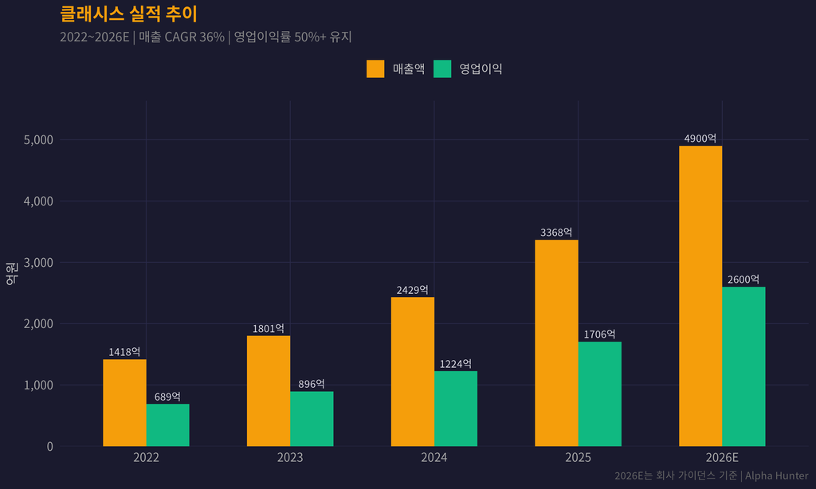

## 2.1 분기별 실적 추세

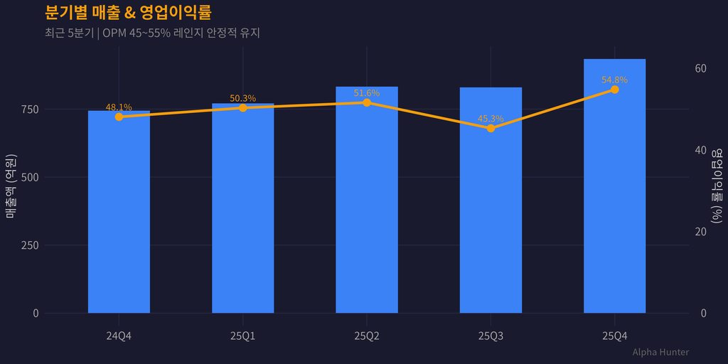

# 3 밸류에이션 비교

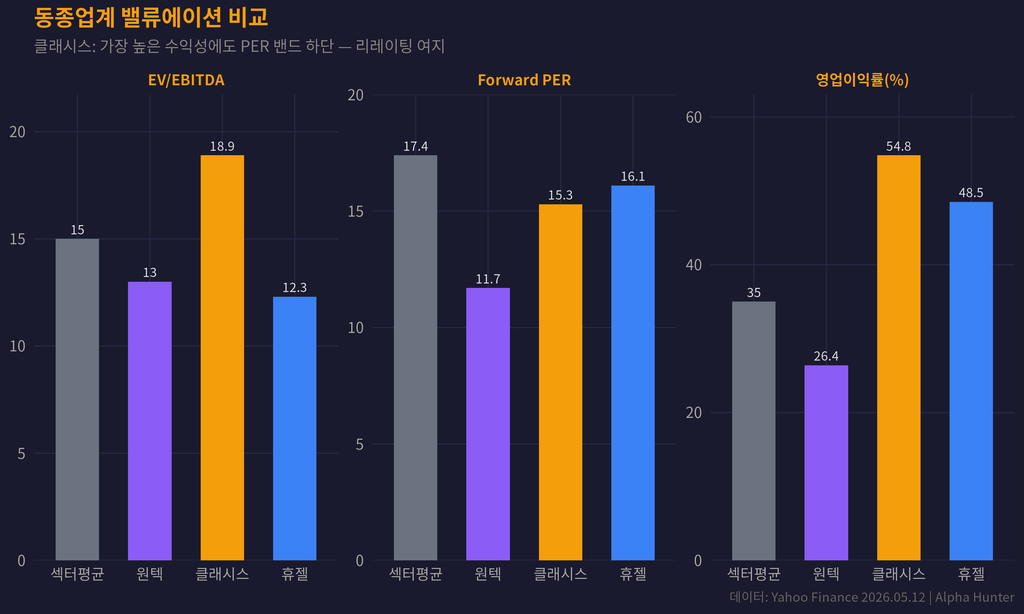

# 4 해자 레이더 차트

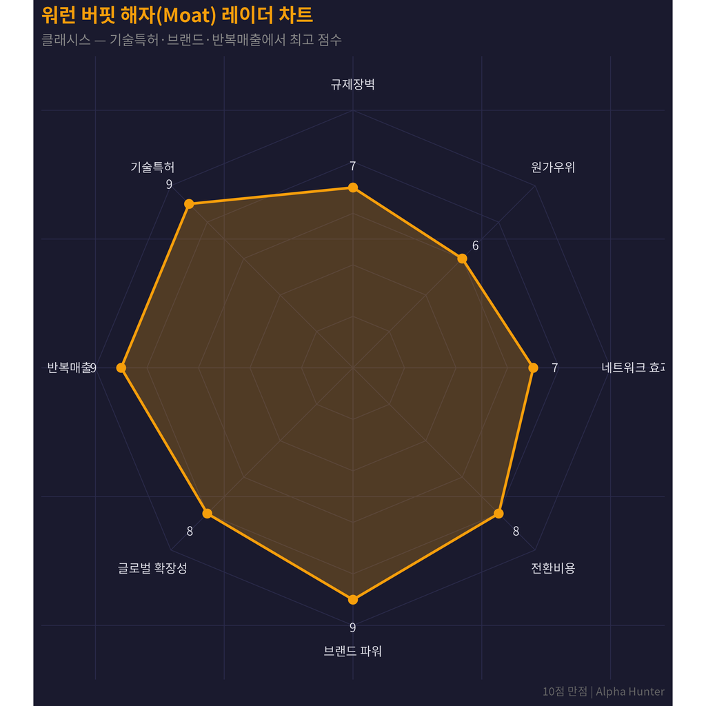

# 5 피터 린치 스토리 점수

[figure not shown]

# 6 리스크 팩터

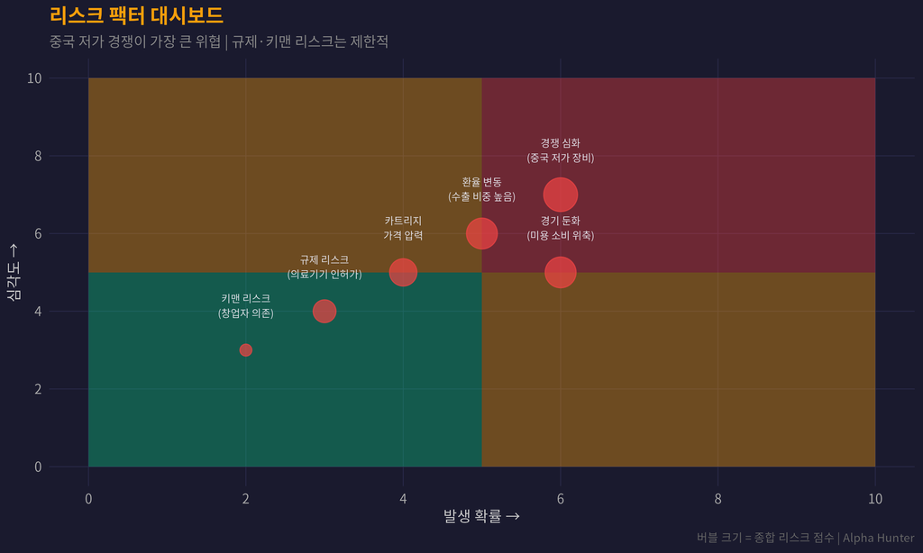

# 7 매수 시나리오

[figure not shown]

# 8 카탈리스트 & 일정

| 시기 | 카탈리스트 | 기대 효과 |
| --- | --- | --- |
| **2026 Q2** | 쿼드세이(MNRF) 미국 론칭 | 신규 매출원 확보, 미국 시장 진입 |
| **2026 H2** | 브라질 메드시스템즈 연결 본격화 | 연간 +500억원 매출 기여 |
| **2026 연간** | 볼뉴머 글로벌 2,000대 설치 목표 | MRF 시장 써마지 대항마 입지 |
| **2026 Q2~** | 유럽 신규 국가(이탈리아·프랑스·영국) 진출 | 지역 다변화, 매출 안정성 제고 |
| **상시** | AI 에너지 제어 기술 R&D | 차세대 제품 경쟁력 강화 |

# 9 결론 & 투자 전략

## 9.1 종합 평가

현재 Forward PER 15.3x는 상장 이후 최저 수준으로, PER밴드 하단(19x)마저 하회하고 있다. 2026년 EPS 성장률 49% 대비 PEG 비율은 0.31x로 극도로 매력적인 밸류에이션이다.

## 9.2 매매 전략

- **적정 매수 구간**: 52,000 ~ 56,000원 (현재가 인근)
- **1차 목표가**: 65,000원 (+19%)
- **컨센서스 목표가**: 79,941원 (+46%)
- **최적 시나리오**: 100,000원 (+83%, PER 27x 회복 시)
- **손절 기준**: 45,000원 (-18%, 52주 최저 하회 시)

> **이 프로젝트는 가상 투자 시뮬레이션 목적으로 작성되었습니다. 실제 투자 권유가 아닙니다.**